# Which Data Science Skills Are Most Valued?

DATA 607 — Project 3

Mohd Afwan Shaikh, Enrique Delamonica, Jocelyn Slater, Lionel Jr Desroses, and Renan Charles-Pierre

October 25, 2026

## Research question

> **Which data science skills are most valued?**

“Valued” isn’t directly observable, so we measure it two ways:

| Proxy | Definition | What it captures |
| --- | --- | --- |
| **Demand** | Share of data-related postings whose description mentions the skill | How often employers ask for it |
| **Pay** | Difference in advertised salary between postings that do and do not mention the skill, before and after adjusting for job category | What employers are willing to pay for it |

## Data and approach

**Kaggle: *Job Postings with Salaries*** (minmaxer)

- Jobs posted in one week on 4,000+ company career sites, with pay ranges
- Snapshot: **October 5–12, 2026**
- Pairs the skills employers ask for with the pay they offer

**Alternatives considered:** CV/resume datasets (what people offer, not what employers want), course descriptions (what schools teach), BLS data (job types, no skills)

9,173  
cleaned job postings

226  
data science postings, 30 tracked skills

178  
with a usable USD salary

## Database design

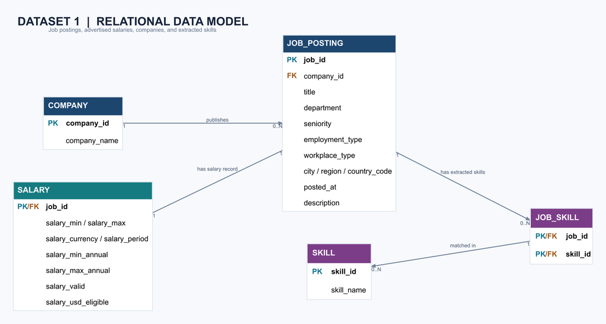

PostgreSQL (`data607_project3`) managed in pgAdmin 4

5 normalized tables: `COMPANY` (210), `JOB_POSTING` (226), `SALARY` (226), `SKILL` (30), `JOB_SKILL` (1,142)

## Data cleaning and quality

**Duplicate checks: all zero**

| Check | Count |
| --- | --- |
| Duplicate job IDs | 0 |
| Duplicate salary job IDs | 0 |
| Duplicate company IDs | 0 |
| Duplicate skill IDs | 0 |
| Duplicate job-skill pairs | 0 |

**Salary status of the 226 postings**

| Status | n |
| --- | --- |
| USD-eligible (used for pay analysis) | 178 |
| Non-USD currency | 44 |
| Outlier flag (< $30K or > $400K) | 4 |

# Value Proxy 1: Demand

## Python and SQL dominate demand

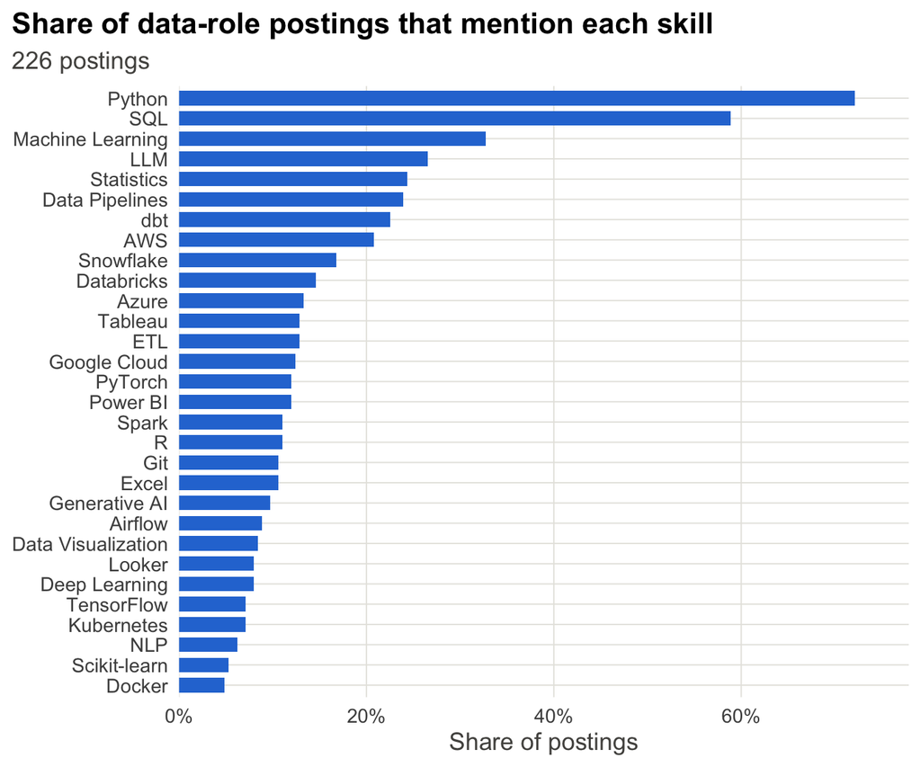

| Skill | Postings | Share |
| --- | --- | --- |
| Python | 163 | 72.1% |
| SQL | 133 | 58.8% |
| Machine Learning | 74 | 32.7% |
| LLM | 60 | 26.5% |
| Statistics | 55 | 24.3% |

## Employers ask for bundles of skills

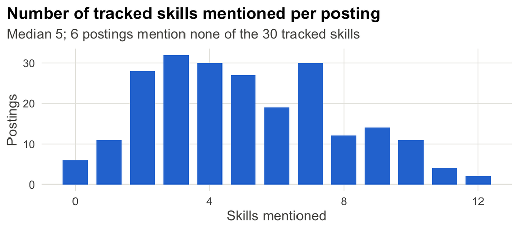

A typical posting names about **5** of our 30 skills.

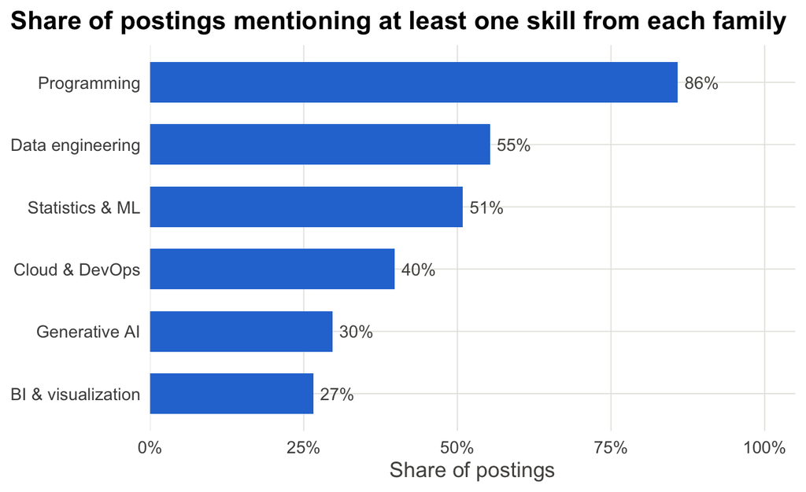

## Demand differs by job category

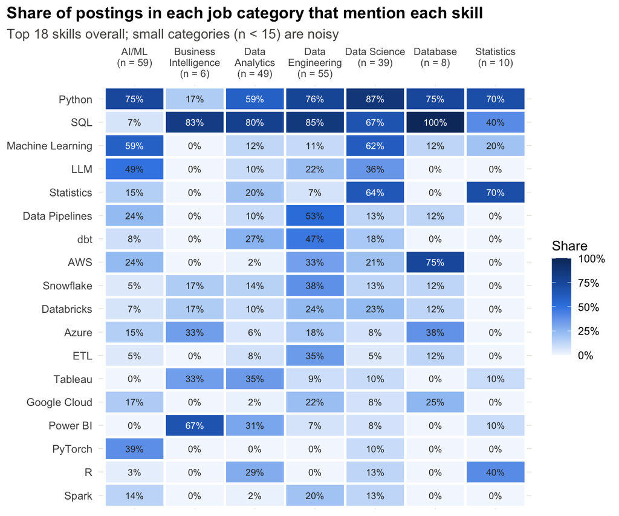

## Each role has its own skill “personality”

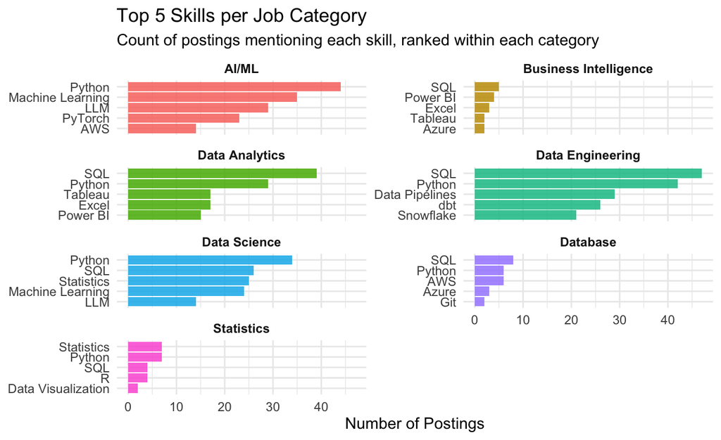

- **AI/ML:** Python, Machine Learning, LLMs, PyTorch. SQL in only 7%
- **Analytics & BI:** SQL + a BI tool (Tableau, Power BI)
- **Data Engineering:** SQL, Python, pipelines, dbt, Snowflake, cloud
- **Python and SQL** are the only skills common (≥ 40%) in nearly every category

## Skills travel together

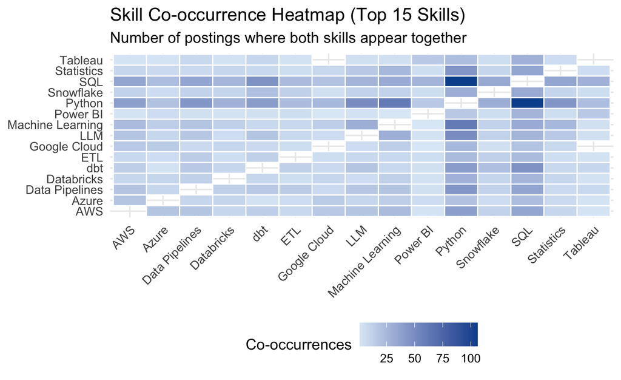

| Skill pair | Postings with both |
| --- | --- |
| Python + SQL | 106 |
| Machine Learning + Python | 61 |
| LLM + Python | 50 |
| dbt + SQL | 47 |
| Python + Statistics | 45 |
| Data Pipelines + Python | 44 |

Python, SQL and Machine Learning form a **core bundle**.

# Value Proxy 2: Pay

## Data science pays well above the market

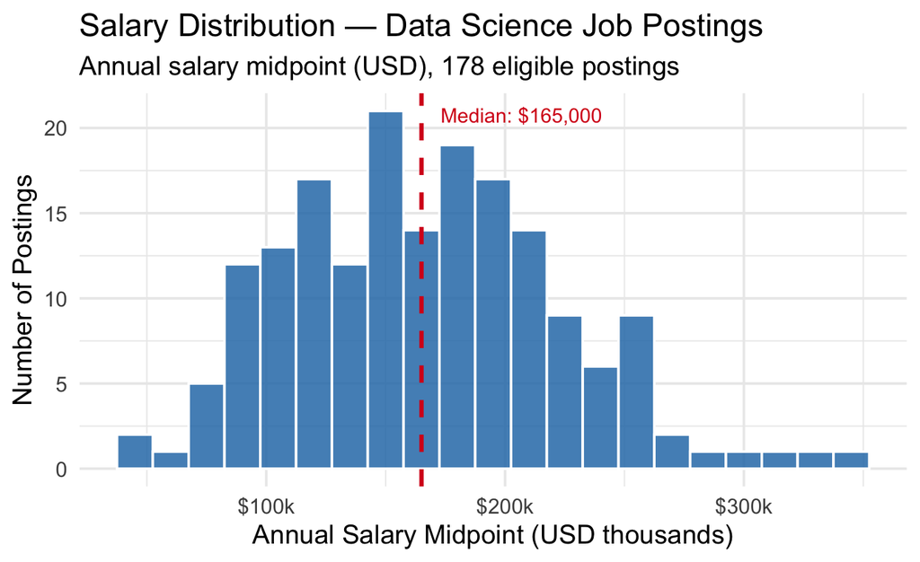

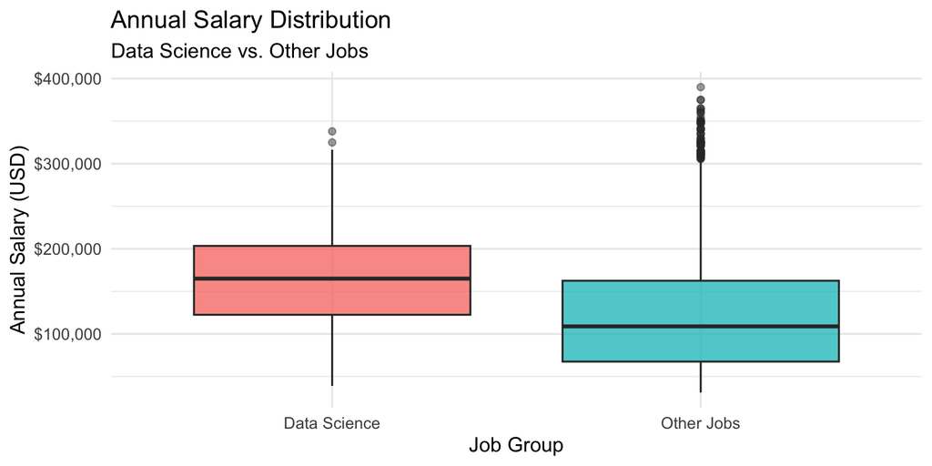

| Group | Postings | Median | Mean | IQR outliers |
| --- | --- | --- | --- | --- |
| Data Science | 178 | $165,000 | $166,885 | 2 (1.1%) |
| Other jobs | 7,412 | $108,875 | $120,410 | 78 (1.1%) |

## Pay depends on the type of role

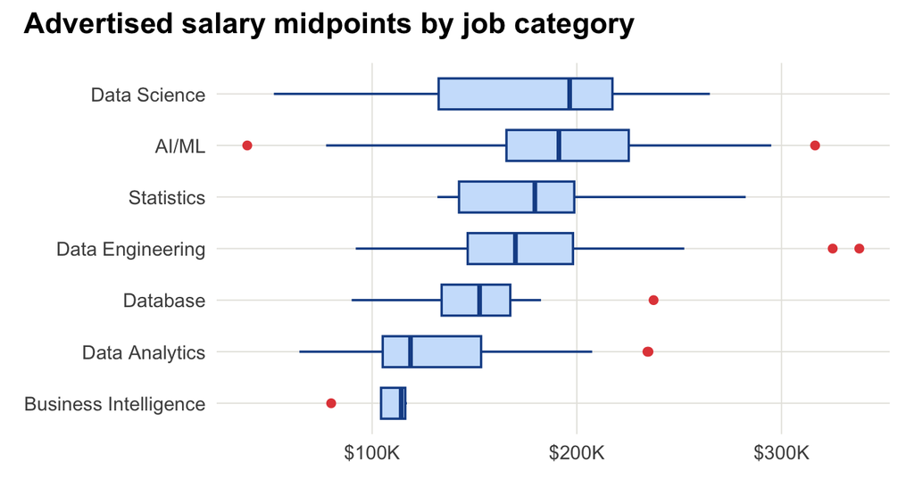

- Data Science and AI/ML pay the most; Data Engineering is in the middle; Data Analytics and BI pay least
- Skills common in AI/ML roles will *look* like they carry a premium even when the role, not the skill, drives pay

## Highest-paying skills

| Skill | Median salary | n |
| --- | --- | --- |
| Generative AI | $196,500 | 15 |
| PyTorch | $195,050 | 23 |
| Deep Learning | $193,300 | 13 |
| LLM | $190,900 | 51 |
| Kubernetes | $185,000 | 15 |
| Machine Learning | $182200 | 59 |
| Data Pipelines | $182,025 | 42 |
| Scikit-learn | $181,775 | 10 |
| Docker | $180,000 | 9 |
| TensorFlow | $180,000 | 13 |
| NLP | $176,800 | 12 |
| Spark | $176,800 | 19 |
| AWS | $169,250 | 40 |

| Skill | Median salary | n |
| --- | --- | --- |
| Airflow | $168,750 | 16 |
| ETL | $168,500 | 23 |
| Google Cloud | $168,500 | 23 |
| Python | $165,000 | 131 |
| Statistics | $164,900 | 44 |
| Snowflak | $164,250 | 32 |
| Looker | 162,972 | 15 |
| dbt | $156,000 | 37 |
| Databricks | $155,000 | 28 |
| SQL | $152,500 | 105 |
| R | $151,160 | 22 |
| Git | $149,216 | 18 |
| Azure | $148,012 | 25 |

## Salary premiums by skill

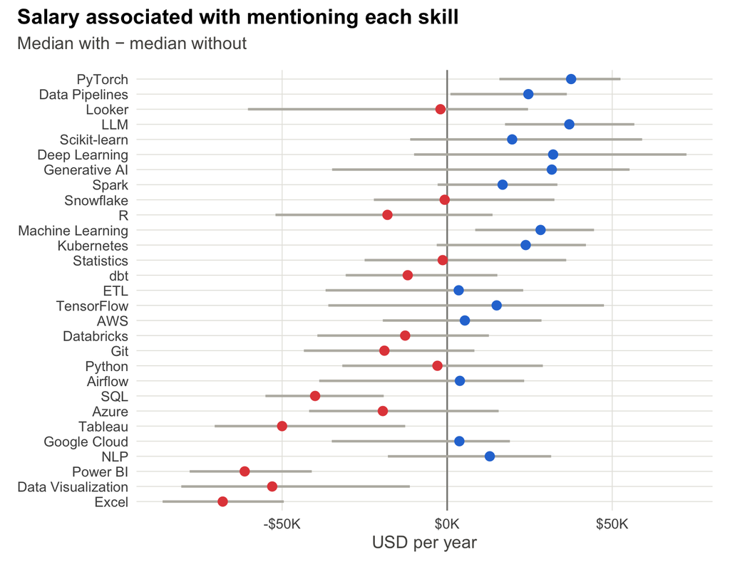

**Association, not causation.** Most confidence intervals include zero (n = 178).

- **ML, LLM, PyTorch:** about **+$28K to +$38K**
- **Excel, Power BI, Tableau, Data Viz:** **$50K–$68K less**
- **SQL:** −$40K, only because AI/ML (highest paid) rarely lists SQL
- **Python:** too common to signal a premium
- Within the same category, Excel (−26%), Data Viz (−23%) and Power BI (−18%) stay lower; these are the only significant estimates (p < 0.05)

# Which Skills Are Most Valued?

## Composite value score

Average of demand rank and salary rank; lower is better.

| Skill | % Postings | Demand Rank | Salary Rank | Value Score | Median Salary |
| --- | --- | --- | --- | --- | --- |
| LLM | 26.5 | 4 | 4 | **4.0** | $190,900 |
| Machine Learning | 32.7 | 3 | 6 | **4.5** | $182,200 |
| Data Pipelines | 23.9 | 6 | 7 | **6.5** | $182,025 |
| Python | 72.1 | 1 | 16 | **8.5** | $165,000 |
| PyTorch | 11.9 | 16 | 2 | **9.0** | $195,050 |
| AWS | 20.8 | 8 | 12 | **10.0** | $169,250 |
| Statistics | 24.3 | 5 | 17 | **11.0** | $164,900 |
| Generative AI | 9.7 | 21 | 1 | **11.0** | $196,500 |
| SQL | 58.8 | 2 | 22 | **12.0** | $152,500 |

## There is no single “most valued” skill

| Tier | Skills | What the data shows |
| --- | --- | --- |
| **Tier 1 — Must Have** | Python, SQL | Asked for in 60–72% of all postings; appear across every job category |
| **Tier 2 — High Value** | Machine Learning, LLMs, Statistics | Tied to the highest-paying roles; growing demand |
| **Tier 3 — Specialist Premium** | PyTorch, Deep Learning, Generative AI | Less common but linked to the largest salary premiums |
| **Tier 4 — Category-Specific** | Spark, Databricks, dbt, Snowflake | Important in Data Engineering; less relevant in analytics roles |

## Key takeaways

1. **Python is the clearest answer.** It is in 72% of postings and appears across every category.
2. **SQL is still essential.** It is in nearly 60% of postings and present in every job type.
3. **AI/ML skills are where the money is.** Generative AI, PyTorch, Deep Learning and LLMs are linked to the highest-paying roles.
4. **Skills travel in bundles.** Python + SQL + Machine Learning is the core stack.
5. **Role type matters as much as skills.** Data Science and AI/ML pay roughly $75K more than Analytics/BI.

## Limitations and future work

**Limitations**

- One-week snapshot (Oct 5–12, 2026)
- Postings from specific applicant-tracking systems; US- and tech-heavy
- Small sample: 226 postings, 178 with salary
- Advertised, not realized, pay; USD only
- Keyword matching can’t tell required from preferred
- No seniority adjustment; associations aren’t causal
- No supply-side (CV) comparison

**Future work**

- Longitudinal tracking with weekly Kaggle updates
- Geographic pay and company comparisons
- Experience-level analysis
- Salary patterns of skill combinations
- Other job-posting and CV datasets
- Models controlling for location, seniority and industry

## Interactive Shiny dashboard

- Built with `shiny`, `bslib`, `dplyr`, `ggplot2`, `plotly`, `DT`
- Developed against PostgreSQL; deployed to **shinyapps.io** from exported CSVs
- Lets users compare data science jobs with the overall market, explore skill demand and salaries, and filter postings

**Live:** [mohdafwan.shinyapps.io/data607-project3](https://mohdafwan.shinyapps.io/data607-project3/)

## Thank you!

Questions?

**Data:** minmaxer. (n.d.). *Job Postings with Salaries* [Data set]. Kaggle. https://www.kaggle.com/datasets/minmaxer/job-postings-with-salaries

**Full project:** `https://github.com/Afwans/DATA607-Project3/tree/main/`

**Dashboard:** https://mohdafwan.shinyapps.io/data607-project3/